# Key Indicators of Heart Disease Among US Residents in 2020 By Team One

# Libraries

```r
library (tidyverse)
library (dplyr)
library (funModeling)
```

```
## funModeling v.1.9.4 :)
## Examples and tutorials at livebook.datascienceheroes.com
##  / Now in Spanish: librovivodecienciadedatos.ai
```

```r
library(ezids)
library (ggplot2)
library(ggcorrplot)
library(corrr)
```

# Load the Data and Rename dataframe

```r
 heart<-data.frame(read.csv("heart_2020_cleaned.csv"))

# Renaming data frame
#heart <- dplyr :: rename (heart_2020_cleaned)
```

# Lets take a look at our data

```r
nrow (heart)
```

```
## [1] 319795
```

# Descrpitive Statistics

```r
status (heart)
```

```
##                          variable q_zeros   p_zeros q_na p_na q_inf p_inf
## HeartDisease         HeartDisease       0 0.0000000    0    0     0     0
## BMI                           BMI       0 0.0000000    0    0     0     0
## Smoking                   Smoking       0 0.0000000    0    0     0     0
## AlcoholDrinking   AlcoholDrinking       0 0.0000000    0    0     0     0
## Stroke                     Stroke       0 0.0000000    0    0     0     0
## PhysicalHealth     PhysicalHealth  226589 0.7085445    0    0     0     0
## MentalHealth         MentalHealth  205401 0.6422896    0    0     0     0
## DiffWalking           DiffWalking       0 0.0000000    0    0     0     0
## Sex                           Sex       0 0.0000000    0    0     0     0
## AgeCategory           AgeCategory       0 0.0000000    0    0     0     0
## Race                         Race       0 0.0000000    0    0     0     0
## Diabetic                 Diabetic       0 0.0000000    0    0     0     0
## PhysicalActivity PhysicalActivity       0 0.0000000    0    0     0     0
## GenHealth               GenHealth       0 0.0000000    0    0     0     0
## SleepTime               SleepTime       0 0.0000000    0    0     0     0
## Asthma                     Asthma       0 0.0000000    0    0     0     0
## KidneyDisease       KidneyDisease       0 0.0000000    0    0     0     0
## SkinCancer             SkinCancer       0 0.0000000    0    0     0     0
##                       type unique
## HeartDisease     character      2
## BMI                numeric   3604
## Smoking          character      2
## AlcoholDrinking  character      2
## Stroke           character      2
## PhysicalHealth     integer     31
## MentalHealth       integer     31
## DiffWalking      character      2
## Sex              character      2
## AgeCategory      character     13
## Race             character      6
## Diabetic         character      4
## PhysicalActivity character      2
## GenHealth        character      5
## SleepTime          integer     24
## Asthma           character      2
## KidneyDisease    character      2
## SkinCancer       character      2
```

We can also see that there are no N/A values in our data set. This is not surprising because our source data was cleaned before.

# Now to see which variables are categorical and which are numerical

```r
data_integrity(heart)
```

```
## $vars_num_with_NA
## [1] variable q_na     p_na
## <0 rows> (or 0-length row.names)
##
## $vars_cat_with_NA
## [1] variable q_na     p_na
## <0 rows> (or 0-length row.names)
##
## $vars_cat_high_card
## [1] variable unique
## <0 rows> (or 0-length row.names)
##
## $MAX_UNIQUE
## [1] 35
##
## $vars_one_value
## character(0)
##
## $vars_cat
##  [1] "HeartDisease"     "Smoking"          "AlcoholDrinking"  "Stroke"
##  [5] "DiffWalking"      "Sex"              "AgeCategory"      "Race"
##  [9] "Diabetic"         "PhysicalActivity" "GenHealth"        "Asthma"
## [13] "KidneyDisease"    "SkinCancer"
##
## $vars_num
## [1] "BMI"            "PhysicalHealth" "MentalHealth"   "SleepTime"
##
## $vars_char
##  [1] "HeartDisease"     "Smoking"          "AlcoholDrinking"  "Stroke"
##  [5] "DiffWalking"      "Sex"              "AgeCategory"      "Race"
##  [9] "Diabetic"         "PhysicalActivity" "GenHealth"        "Asthma"
## [13] "KidneyDisease"    "SkinCancer"
##
## $vars_factor
## character(0)
##
## $vars_other
## character(0)
```

# Description of every variable

```r
describe (heart)
```

```
## heart
##
##  18  Variables      319795  Observations
## --------------------------------------------------------------------------------
## HeartDisease
##        n  missing distinct
##   319795        0        2
##
## Value          No    Yes
## Frequency  292422  27373
## Proportion  0.914  0.086
## --------------------------------------------------------------------------------
## BMI
##        n  missing distinct     Info     Mean      Gmd      .05      .10
##   319795        0     3604        1    28.33    6.778    20.12    21.47
##      .25      .50      .75      .90      .95
##    24.03    27.34    31.42    36.49    40.18
##
## lowest : 12.02 12.08 12.13 12.16 12.20, highest: 92.53 93.86 93.97 94.66 94.85
## --------------------------------------------------------------------------------
## Smoking
##        n  missing distinct
##   319795        0        2
##
## Value          No    Yes
## Frequency  187887 131908
## Proportion  0.588  0.412
## --------------------------------------------------------------------------------
## AlcoholDrinking
##        n  missing distinct
##   319795        0        2
##
## Value          No    Yes
## Frequency  298018  21777
## Proportion  0.932  0.068
## --------------------------------------------------------------------------------
## Stroke
##        n  missing distinct
##   319795        0        2
##
```

[output cut: 107 more lines]

```
##        n  missing distinct
##   319795        0        2
##
## Value          No    Yes
## Frequency  308016  11779
## Proportion  0.963  0.037
## --------------------------------------------------------------------------------
## SkinCancer
##        n  missing distinct
##   319795        0        2
##
## Value          No    Yes
## Frequency  289976  29819
## Proportion  0.907  0.093
## --------------------------------------------------------------------------------
```

# Finding the mean of numerical variables grouped by heart disease

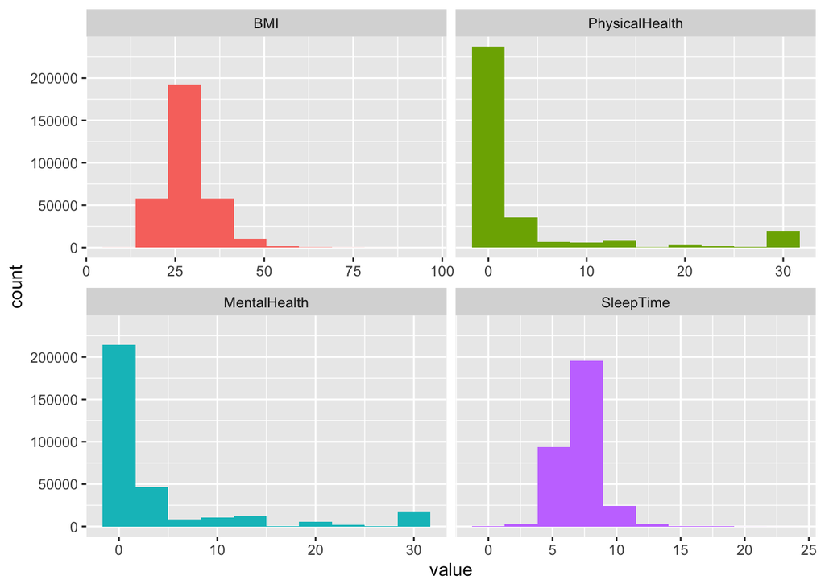

```r
plot_num(heart)
```

```r
heart %>%
  group_by(HeartDisease) %>%
  summarise_at(vars("BMI",
                    "PhysicalHealth",
                    "MentalHealth",
                    "SleepTime"), mean)
```

```
## # A tibble: 2 × 5
##   HeartDisease   BMI PhysicalHealth MentalHealth SleepTime
##   <chr>        <dbl>          <dbl>        <dbl>     <dbl>
## 1 No            28.2           2.96         3.83      7.09
## 2 Yes           29.4           7.81         4.64      7.14
```

On average, people with heart disease have a slightly higher BMI than those who don’t have heart disease. However, the biggest difference is the number of days that a respondent feels physically unwell. HD people reported feeling physically unwell about 8 days per month, while healthy people felt unwell for only 3.

# Frequency distributions of all our categorical variables

```r
freq(heart)
```

```
##   HeartDisease frequency percentage cumulative_perc
## 1           No    292422      91.44           91.44
## 2          Yes     27373       8.56          100.00
```

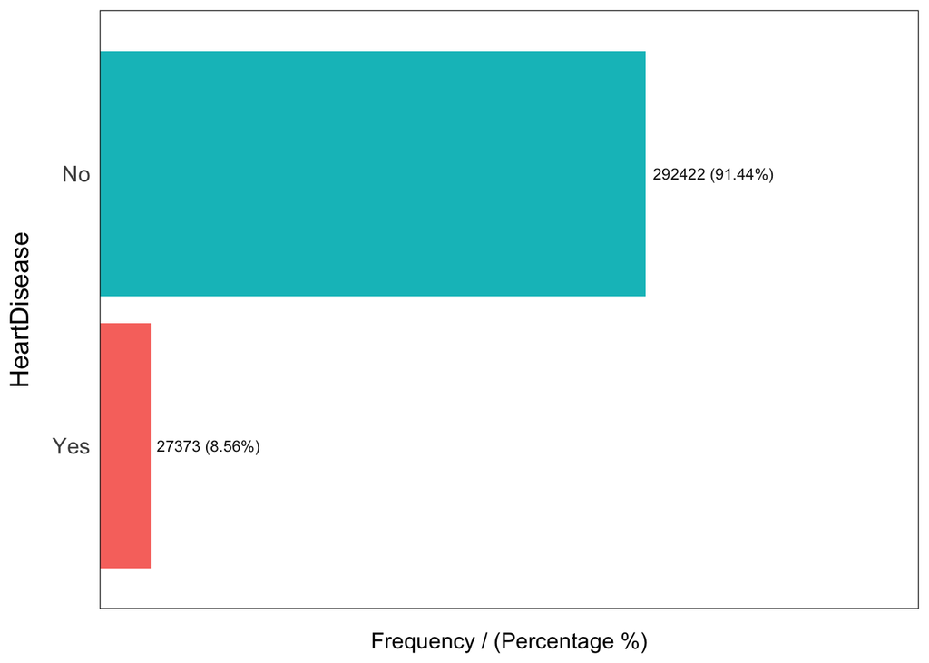

```
##   Smoking frequency percentage cumulative_perc
## 1      No    187887      58.75           58.75
## 2     Yes    131908      41.25          100.00
```

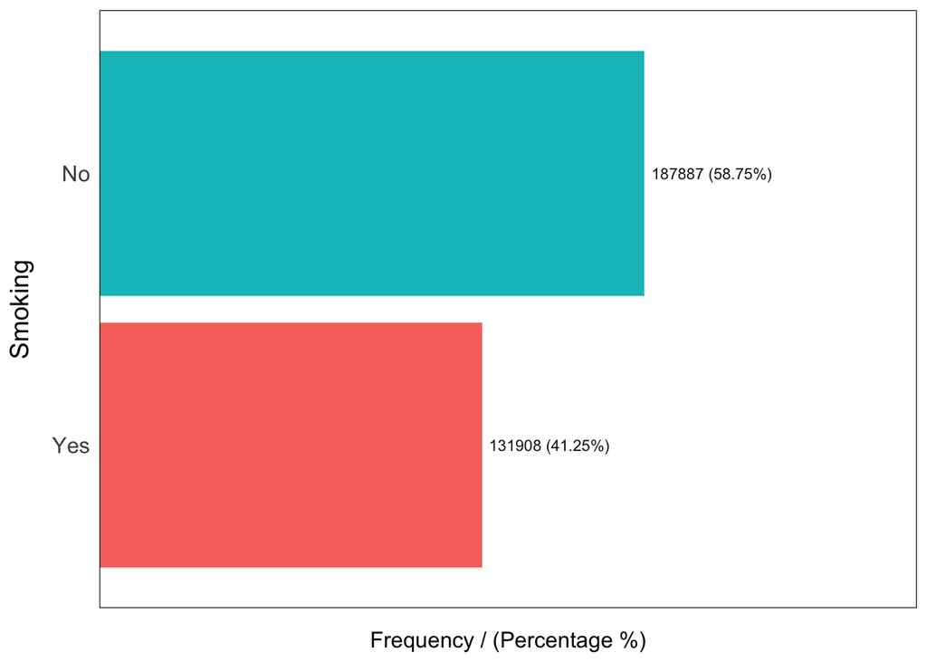

```
##   AlcoholDrinking frequency percentage cumulative_perc
## 1              No    298018      93.19           93.19
## 2             Yes     21777       6.81          100.00
```

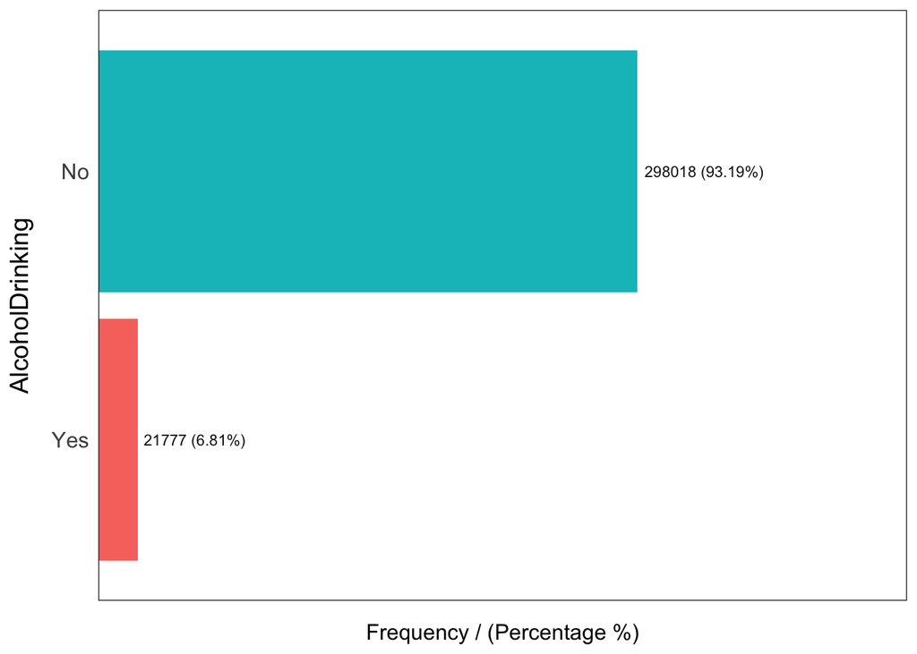

```
##   Stroke frequency percentage cumulative_perc
## 1     No    307726      96.23           96.23
## 2    Yes     12069       3.77          100.00
```

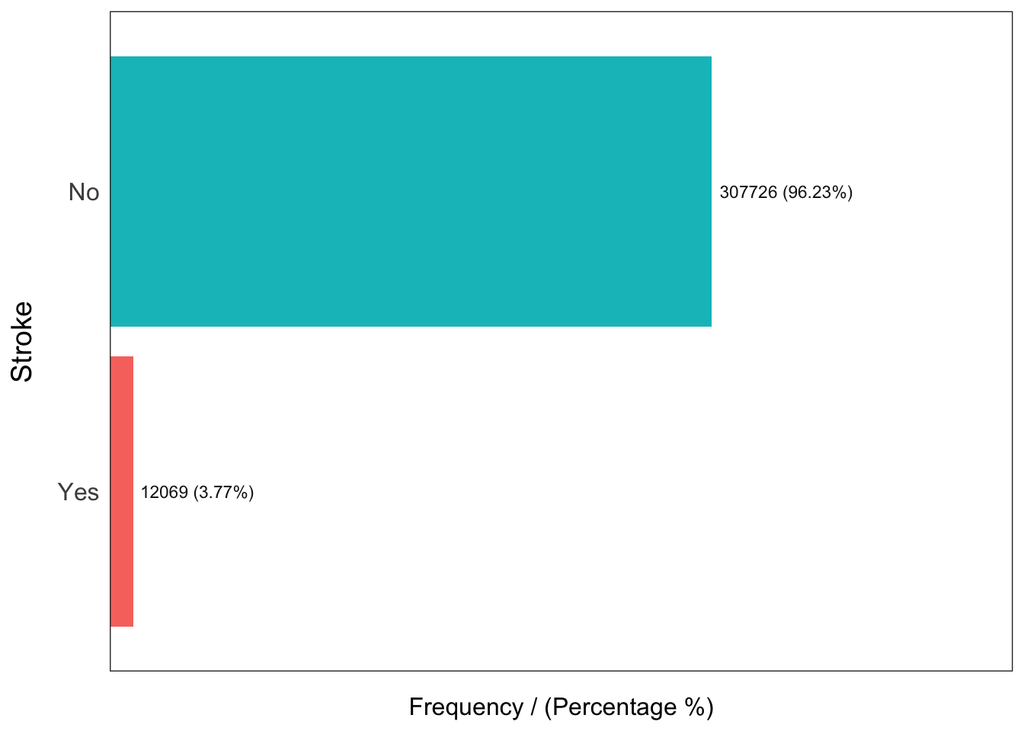

```
##   DiffWalking frequency percentage cumulative_perc
## 1          No    275385      86.11           86.11
## 2         Yes     44410      13.89          100.00
```

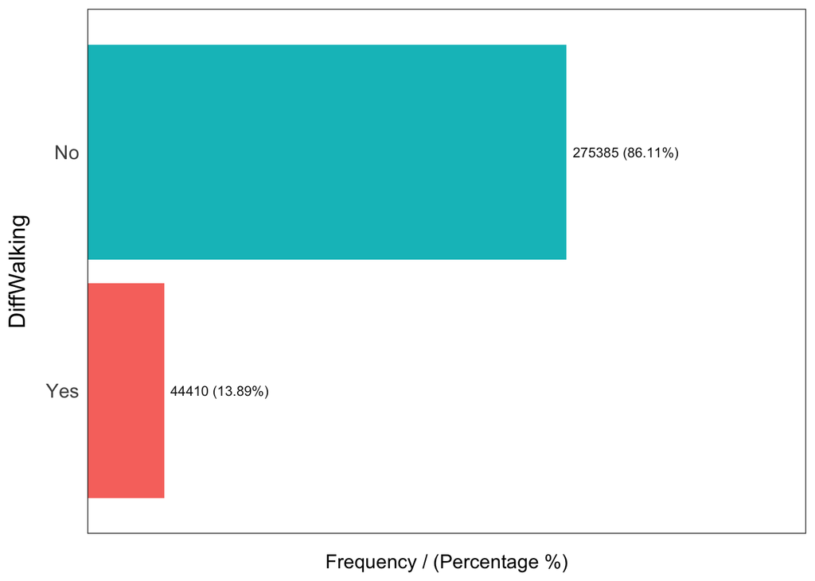

```
##      Sex frequency percentage cumulative_perc
## 1 Female    167805      52.47           52.47
## 2   Male    151990      47.53          100.00
```

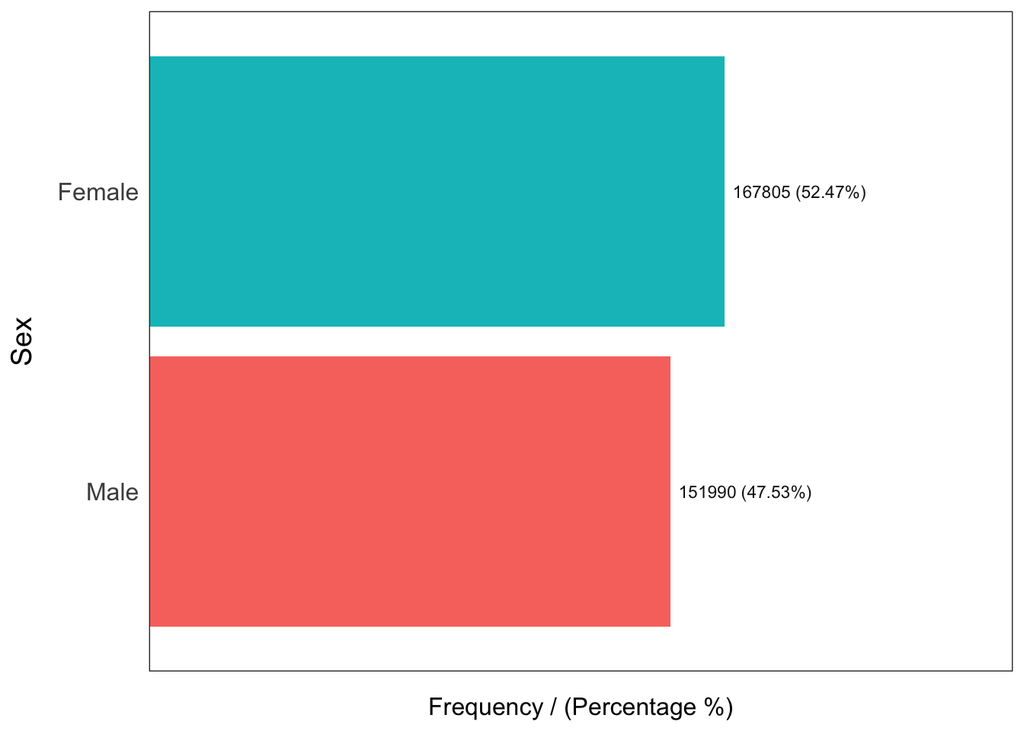

```
##    AgeCategory frequency percentage cumulative_perc
## 1        65-69     34151      10.68           10.68
## 2        60-64     33686      10.53           21.21
## 3        70-74     31065       9.71           30.92
## 4        55-59     29757       9.31           40.23
## 5        50-54     25382       7.94           48.17
## 6  80 or older     24153       7.55           55.72
## 7        45-49     21791       6.81           62.53
## 8        75-79     21482       6.72           69.25
## 9        18-24     21064       6.59           75.84
## 10       40-44     21006       6.57           82.41
## 11       35-39     20550       6.43           88.84
## 12       30-34     18753       5.86           94.70
## 13       25-29     16955       5.30          100.00
```

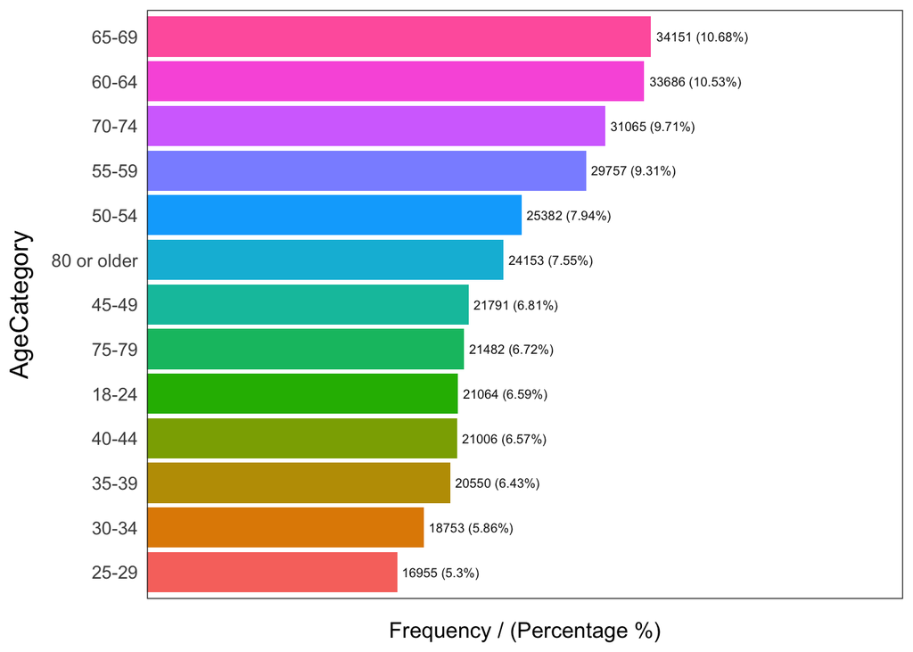

```
##                             Race frequency percentage cumulative_perc
## 1                          White    245212      76.68           76.68
## 2                       Hispanic     27446       8.58           85.26
## 3                          Black     22939       7.17           92.43
## 4                          Other     10928       3.42           95.85
## 5                          Asian      8068       2.52           98.37
## 6 American Indian/Alaskan Native      5202       1.63          100.00
```

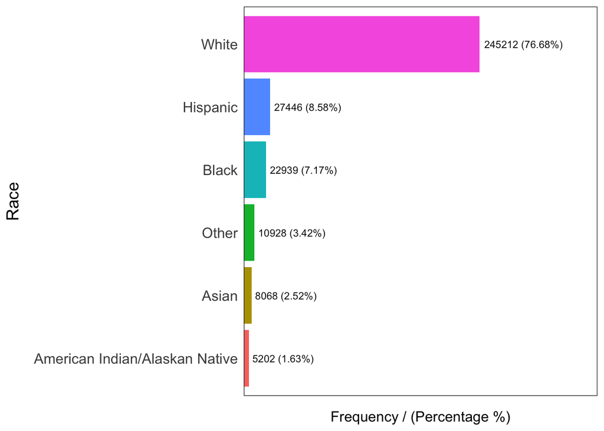

```
##                  Diabetic frequency percentage cumulative_perc
## 1                      No    269653      84.32           84.32
## 2                     Yes     40802      12.76           97.08
## 3 No, borderline diabetes      6781       2.12           99.20
## 4  Yes (during pregnancy)      2559       0.80          100.00
```

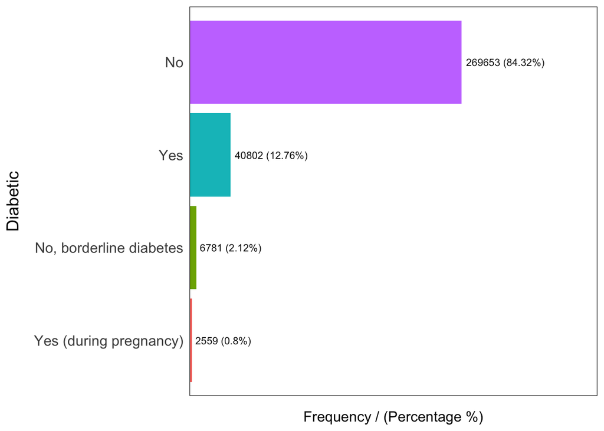

```
##   PhysicalActivity frequency percentage cumulative_perc
## 1              Yes    247957      77.54           77.54
## 2               No     71838      22.46          100.00
```

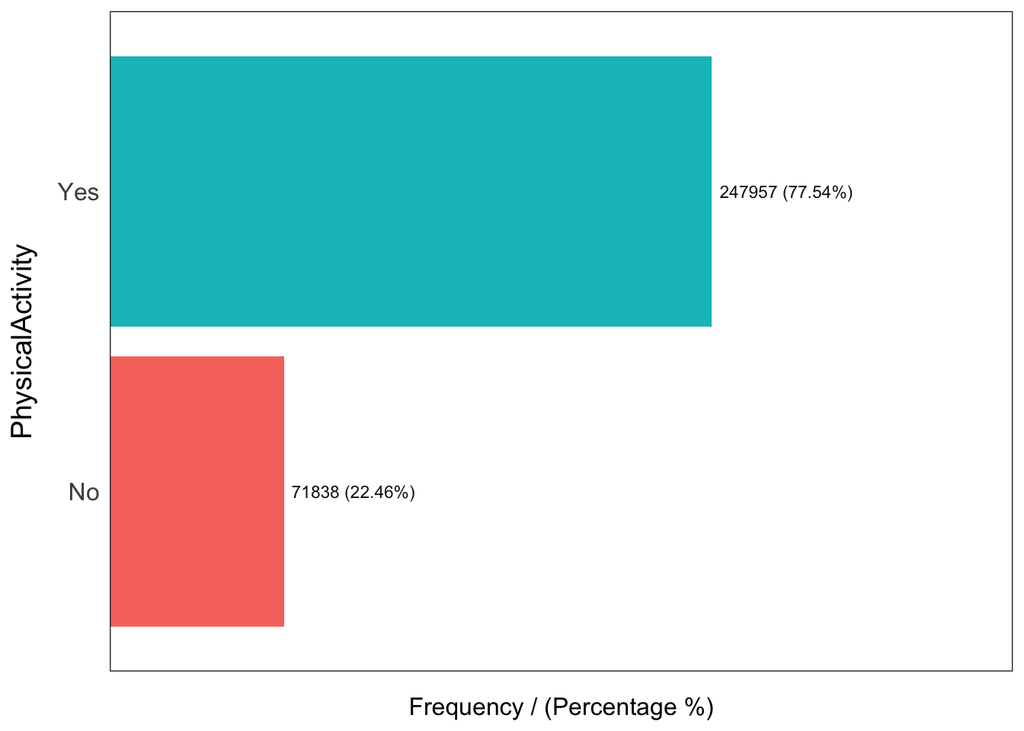

```
##   GenHealth frequency percentage cumulative_perc
## 1 Very good    113858      35.60           35.60
## 2      Good     93129      29.12           64.72
## 3 Excellent     66842      20.90           85.62
## 4      Fair     34677      10.84           96.46
## 5      Poor     11289       3.53          100.00
```

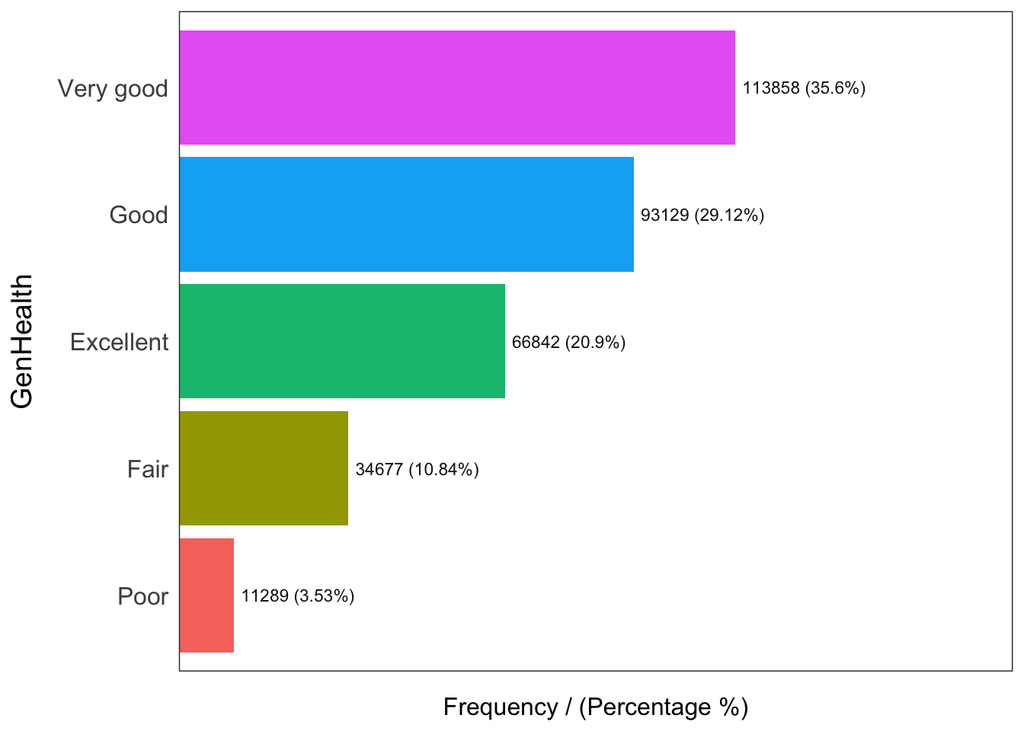

```
##   Asthma frequency percentage cumulative_perc
## 1     No    276923      86.59           86.59
## 2    Yes     42872      13.41          100.00
```

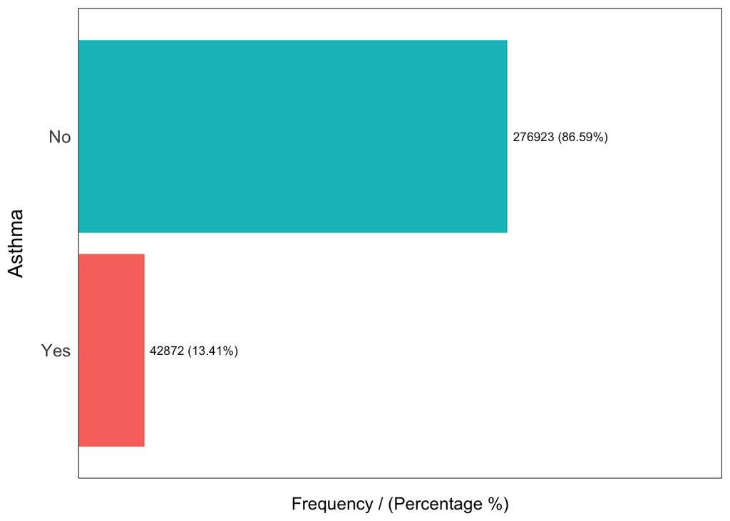

```
##   KidneyDisease frequency percentage cumulative_perc
## 1            No    308016      96.32           96.32
## 2           Yes     11779       3.68          100.00
```

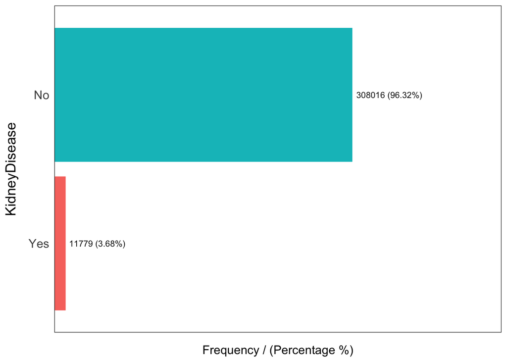

[figure not shown]

```
##   SkinCancer frequency percentage cumulative_perc
## 1         No    289976      90.68           90.68
## 2        Yes     29819       9.32          100.00
```

```
## [1] "Variables processed: HeartDisease, Smoking, AlcoholDrinking, Stroke, DiffWalking, Sex, AgeCategory, Race, Diabetic, PhysicalActivity, GenHealth, Asthma, KidneyDisease, SkinCancer"
```

# Changing Diabetes bordeline and pregnancy categories to Yes/No

```r
heart$Diabetic<- replace (heart$Diabetic, heart$Diabetic== "No, borderline diabetes" , "Yes")
heart$Diabetic[heart$Diabetic== "Yes (during pregnancy)"] <- "No"
```

#Checking if diabetic has been changed

```r
describe (heart$Diabetic)
```

```
## heart$Diabetic
##        n  missing distinct
##   319795        0        2
##
## Value          No    Yes
## Frequency  272212  47583
## Proportion  0.851  0.149
```

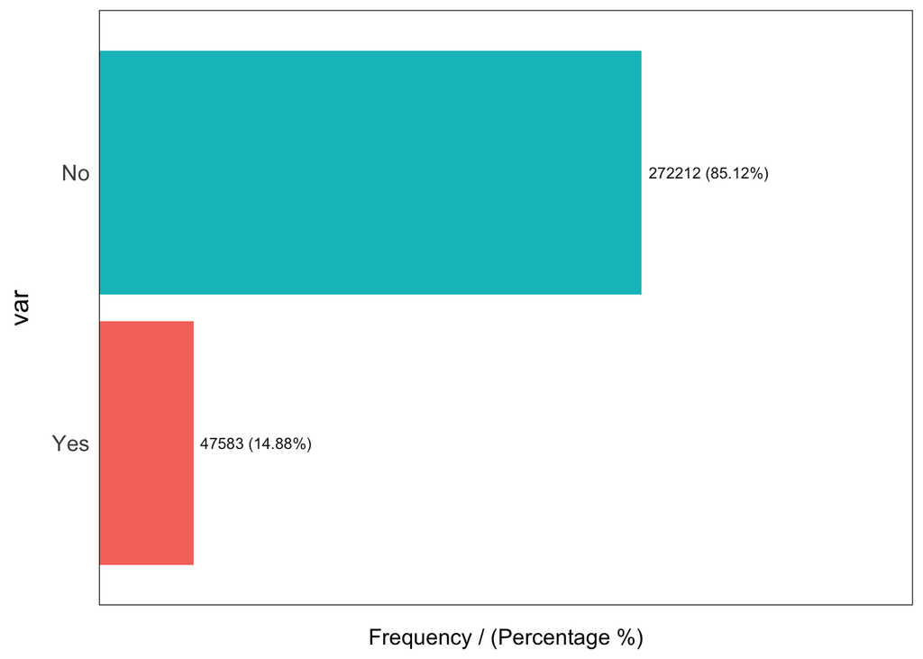

```
##   var frequency percentage cumulative_perc
## 1  No    272212      85.12           85.12
## 2 Yes     47583      14.88          100.00
```

```r
freq(heart$Diabetic)
```

# Changing all the categorical variables to numerical dummies

```r
heart$heartDisease<-ifelse(heart$HeartDisease=="Yes",1,0)
heart$Smoking<-ifelse(heart$Smoking=="Yes",1,0)
heart$AlcoholDrinking<-ifelse(heart$AlcoholDrinking=="Yes",1,0)
heart$Stroke<-ifelse(heart$Stroke=="Yes",1,0)
heart$DiffWalking<-ifelse(heart$DiffWalking=="Yes",1,0)
heart$PhysicalActivity<-ifelse(heart$PhysicalActivity=="Yes",1,0)
heart$KidneyDisease<-ifelse(heart$KidneyDisease=="Yes",1,0)
heart$SkinCancer<-ifelse(heart$SkinCancer=="Yes",1,0)
heart$Diabetic<-ifelse(heart$Diabetic=="Yes",1,0)
heart$Asthma<-ifelse(heart$Asthma=="Yes",1,0)
```

#Correlation Plots of all variables

[figure not shown]

```r
 model.matrix(~0+., data=heart) %>%
     cor(use="pairwise.complete.obs") %>%
   ggcorrplot(show.diag = F, type="upper", lab=TRUE, lab_size=2)
```

Need bigger screen to see this corrplot properly

## Which gender is more likely to get heart disease?

# Contingency Table for Sex & heart Disease

```r
contable = table(heart$HeartDisease, heart$Sex)
xkabledply(contable, title="Contingency Table for heart Disease and Sex")
```

Contingency Table for heart Disease and Sex

|  | Female | Male |
| --- | --- | --- |
| No | 156571 | 135851 |
| Yes | 11234 | 16139 |

```r
addmargins(contable)
```

```
##
##       Female   Male    Sum
##   No  156571 135851 292422
##   Yes  11234  16139  27373
##   Sum 167805 151990 319795
```

```r
prop <-prop.table(contable)
percent <- round(prop*100, 2)

print ("Contingency Table for heart Disease and Sex in Percentage")
```

```
## [1] "Contingency Table for heart Disease and Sex in Percentage"
```

```r
print (percent)
```

```
##
##       Female  Male
##   No   48.96 42.48
##   Yes   3.51  5.05
```

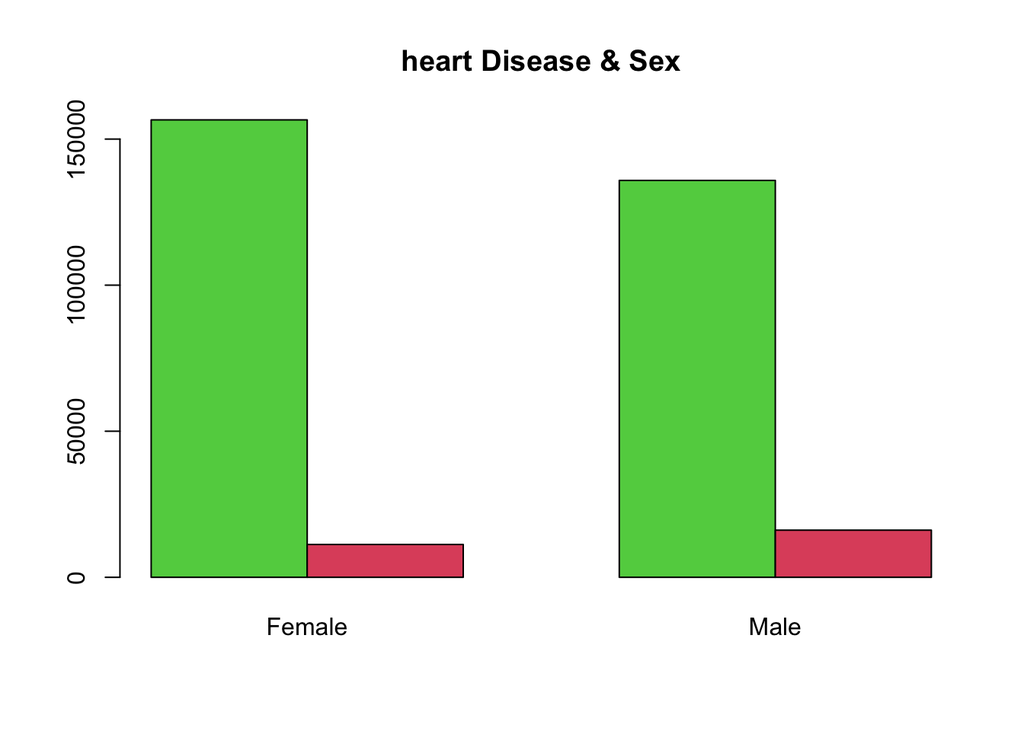

```r
barplot(with(heart, table(HeartDisease, Sex)), main="heart Disease & Sex", beside=T, col=3:2)
```

Green (No HD): more women Red (HD): More men More men tend to have heart disease than women (Look at percentage chart)

# Subset Male & Female

```r
female <- subset(heart, Sex== "Female")
male  <- subset (heart, Sex == "Male")
```

# Male heart Disease Boxplot

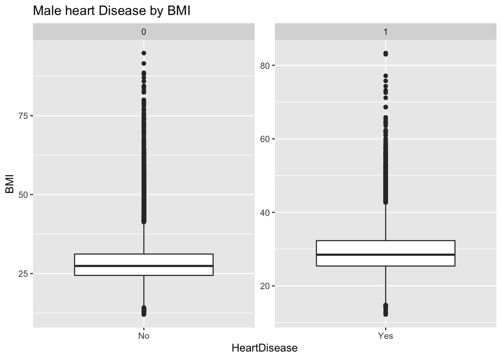

```r
ggplot(male, aes(x=HeartDisease, y=BMI)) +
    geom_boxplot() +
    facet_wrap(~heartDisease, scale="free") +
    ggtitle("Male heart Disease by BMI")
```

# Female heart Disease by BMI

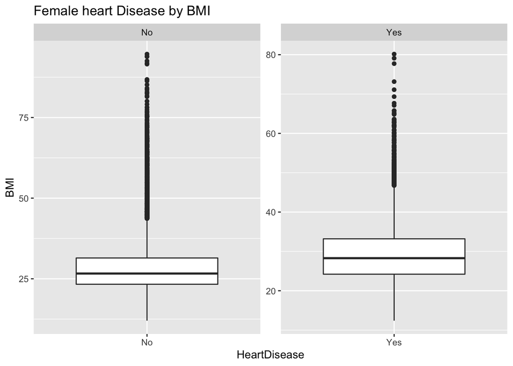

```r
ggplot(female, aes(x=HeartDisease, y=BMI)) +
    geom_boxplot() +
    facet_wrap(~HeartDisease, scale="free") +
    ggtitle("Female heart Disease by BMI")
```

# Are there differences between the means of the sexes

```r
t.test(female$BMI, male$BMI)
```

```
##
##  Welch Two Sample t-test
##
## data:  female$BMI and male$BMI
## t = -15.368, df = 318168, p-value < 2.2e-16
## alternative hypothesis: true difference in means is not equal to 0
## 95 percent confidence interval:
##  -0.3866106 -0.2991518
## sample estimates:
## mean of x mean of y
##  28.16244  28.50532
```

The p-value is less than 0.05% significance level, allowing us to reject the null hypothesis and conclude that the overall average BMI is different between the male and female populations.

# Is there a difference between the sex with heart disease

```r
female_HD<- subset(female, HeartDisease==1)
male_HD<- subset(male, HeartDisease== 1)

 sex_bmi <-t.test(female_HD$BMI,
                  male_HD$BMI)
```

```
## Error in t.test.default(female_HD$BMI, male_HD$BMI): not enough 'x' observations
```